# R Markdown Session Handout

Alison Blaine

October 24, 2017

## Hands-On Session

This will be a hands-on session.

## Access to RStudio server

Make sure to get a paper slip with a URL and login information to an RStudio server instance.

**URL: check your slip**  
**username: check your slip**  
**password: check your slip**

## About Me

- work at NCSU Libraries
- Digital Library Initiatives: github.com/ncsu-libraries
- consulting, teaching & coding
- we have lots of R Users who need to publish

## Old Model of a Research Document

A document and its elements as static entities:

- document
- figures
- data tables
- appendices

## New Model: Dynamic Research Document

- A document where everything is contained that you need to re-run the experiment or models that produced the data. Including the code.
- A document that is not siloed in a particular tool (Word doc) but can be easily converted to other types.
- A document that can contain interactive visualizations and embedded apps.
- A document that could be its own web app, github page, or slide presentation.

## Wouldn’t it be Cool if…

You could use the same open-source tool for your data cleaning, analysis and publishing?

## What is R?

R is a programming language for statistical computing and graphics.

- New Zealand
- created by statisticians named **Ross** and **Robert**
- robust user community
- relative obscurity in early 2000s –> top languages for data science today

[figure not shown]

## R Packages

Base R is extended by packages that can be imported into R. Currently there are over 13,000 registered packages. Find packages at RDocumentation.org

[figure not shown]

## R Studio

[figure not shown]

## What is R Markdown?

**R Markdown** is a version of Markdown, a **text markup tool**, adapted for use in R.

R Markdown documents are fully reproducible and support dozens of static and dynamic output formats.

[figure not shown]

## R Markdown Lets Us Have Nice Things

[figure not shown]

One .Rmd file –> many types of documents:

- HTML files / websites
- PDF
- Microsoft Word
- Interactive documents (Shiny apps)
- Slide presentations
- Books
- Journal articles

image credit: [R Studio](http://rmarkdown.rstudio.com/)

## Reproducibility

- other people can re-run your code
- transparency for other researchers
- files are dynamic
- easy to share

## Versatility

In an R Markdown file, you can include:

- HTML
- LaTeX
- mathjax
- code chunks in other languages

```
## R Markdown Lets Us Have Nice Things

<img style="float: right;" src="images/RMarkdownOutputFormats.png">

One .Rmd file --> many types of documents:

- HTML files / websites
- PDF
- Microsoft Word
- Interactive documents (Shiny apps)
- Slide presentations
- Books
- Journal articles
```

## R packages for document creation

- **pandoc** - converts documents from one markup format to another
- **rmarkdown** - reads R Markdown. Already included with RStudio.
- **knitr** - generates dynamic reports. Already included with RStudio.
- **LaTeX (for PDFs)** - for Typesetting, useful for math notation and journal article formatting
- **bookdown** - if you want to write books

[More information](http://stackoverflow.com/questions/40563479/relationship-between-r-markdown-knitr-pandoc-and-bookdown) about how these packages work together

## How it works

An R Markdown file (.Rmd) is the file that you will use to create your document.

A typical file has three components:

- header
- code chunks
- text

## Header

```
---
title: "R Markdown for Publishing Documents"
author: "Alison Blaine"
date: "October 2017"
output: html_document
---
```

Written in YAML, a format common for configuration files

**Output options**:

html_document, pdf_document, word_document, md_document, ioslides_presentation, slidy_presentation, beamer_presentation, revealjs_presentation (revealjs package must be installed)

## Header Options: CSS

- You can add a [CSS (Cascading Style Sheet)](https://en.wikipedia.org/wiki/Cascading_Style_Sheets) file to your project if you want to change the styling of your document.
- The CSS file must be included in your project directory and named in the header.

```
 ---
 title: "R Markdown for Publishing Documents"
 output:
   slidy_presentation:
      css: styles.css
---
```

## Header Options: Table of Contents

```
---
title: "R Markdown for Publishing Documents"
output:
  html_document:
    toc: true
    toc_float: true
    number_sections: true
---
```

## Header for this Presentation

```
---
title: "R Markdown for Publishing Documents"
author: "Alison Blaine"
date: "NCSU Libraries"
output:
  revealjs::revealjs_presentation:
    theme: blood
    highlight: zenburn
    transition: slide
---
```

## Code chunks

Make a code chunk with 3 backticks then {r}. End chunk with 3 backticks:

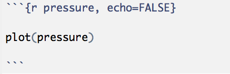

## Example

```r
attach(mtcars)
plot(wt, mpg, main="Scatterplot Example",
    xlab="Car Weight ", ylab="Miles Per Gallon ", pch=19)
```

[output not shown]

## Chunk options

Using chunk options, you can set rules for your code chunks.

- to specify the dimensions of a figure
- to make it so a code chunk does not appear in the final document
- to show or hide the code in the code chunk
- to display or not display error messages generated by the code

`{r echo=TRUE, eval=FALSE}`

## Example 1

`{r echo=TRUE}`

```r
plot(wt, mpg, main="Scatterplot Example",
    xlab="Car Weight ", ylab="Miles Per Gallon ", pch=19)
```

[output not shown]

## Example 2

`{r echo=FALSE}`

## Global Chunk Options

These provide rules for all of the chunks in the document.

Example: `knitr::opts_chunk$set(echo = FALSE)`

[figure not shown]

## Text

Formatting text requires R Markdown notation. See R Markdown Reference Guide for more examples.

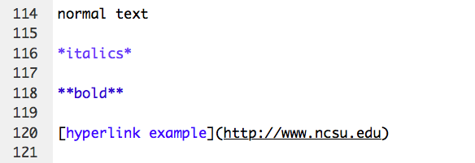

normal text  
*italics*  
**bold**  
[hyperlink example](http://www.ncsu.edu)

## Rendering Your R Markdown File

Save your .Rmd file, and click the *“Knit”* button that appears above the file.

You can set certain output options by clicking on the gear icon next to the Knit button.

## Templates

There are existing R Markdown templates for html files, slide shows, and scholarly journal article formats.

- github document
- Package Vignette (HTML)
- [tufte](http://rstudio.github.io/tufte/) is a template for handouts in the style of Edward Tufte.
- rticles is a LaTeX academic journal R package.

To use a template, you can install a template package or download it from the source:

install.packages(“rticles”, type = “source”)

## Opening a Template from Installed Package in RStudio

After installing the rticles package:

1. File > New File > R Markdown…
2. Select “From Template”

The window should populate with templates from the rticles package

Note: a *full installation of LaTeX is required* for this to work.

## Hands-On Part Begins

[figure not shown]

## Log in to R Studio

Use the paper slip on to log in to RStudio:

### **URL: check your slip**

#### **username: check your slip**

#### **password: check your slip**

## Open the Cheatsheet

In RStudio, go to `Help > Cheatsheets > R Markdown Reference Guide`

## Exercise 1: Create an R Markdown file

1. **Log in to RStudio at go.ncsu.edu/ato** (or open RStudio on your computer)
2. File > New File > R Markdown
3. Select HTML
4. Title it “HelloWorld”
5. Click the save button. Save as “HelloWorld”
6. Click “Knit Html” to see it render as an HTML file

## Change Your Global Chunk Option

Try setting your global chunk option to the following. Each time, knit the code to see changes.

`knitr::opts_chunk$set(echo = FALSE)`

`knitr::opts_chunk$set(eval = FALSE)`

## Knit as an Open Office or PDF Doc

Change `output: html_document` to `output: odt_document` or `output: pdf_document`.

```
---
title: "Hello World"
author: "Alison Blaine"
date: "10/11/2017"
output: pdf_document
---
```

## Exercise 2: Open Nile.Rmd file

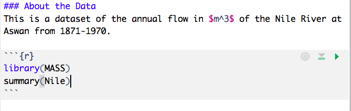

## Overview of Nile.Rmd

This document is about the annual flow (in $m^3$) of the Nile River at Aswan from 1871–1970.

Inside your code chunk should be two commands:

```r
library(MASS)
summary(Nile)
```

[output not shown]

`library(MASS)` - loads the MASS library of sample datasets  
`summary(Nile)` - shows the statistical summary of the data set

## Add a plot

Skip a line and then **create a new R code chunk** under the previous one. Add a plot inside the chunk with the following command:

```
plot(Nile)
```

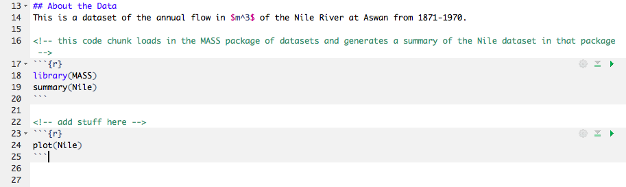

## Title the Plot

`## Flow Over Time`

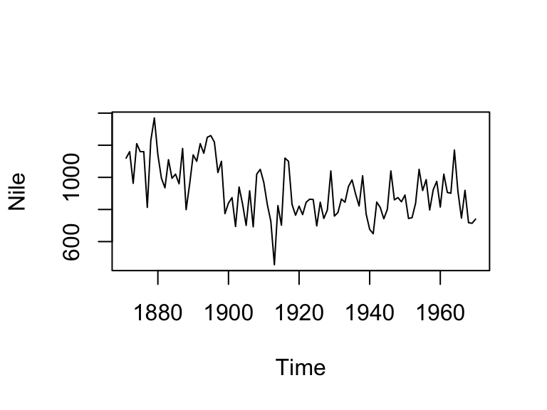

## Resize the plot by adding a chunk option

Knit when you’re finished!

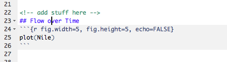

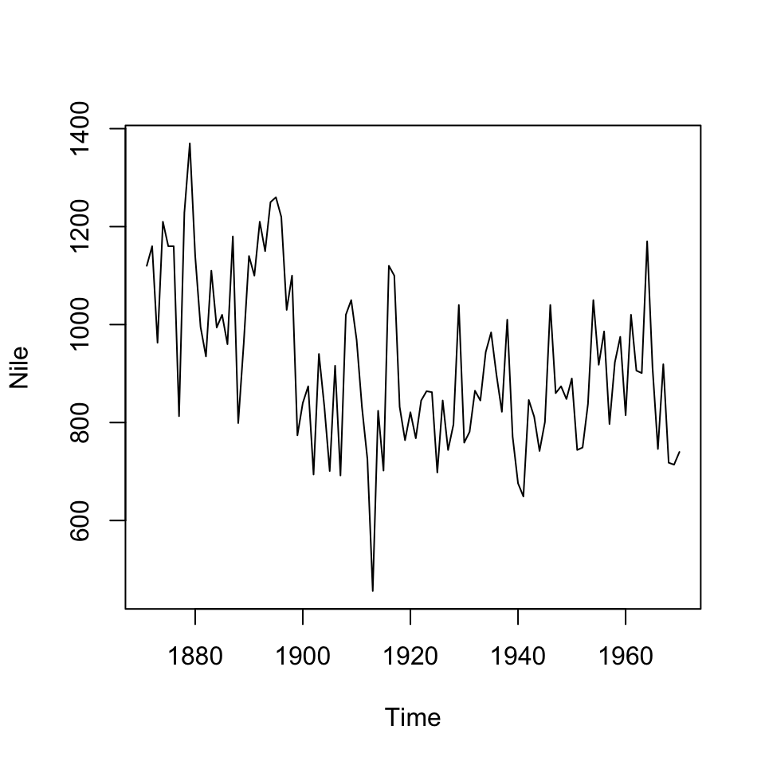

## Create a new section

```
## Distribution
```

## Add a Histogram

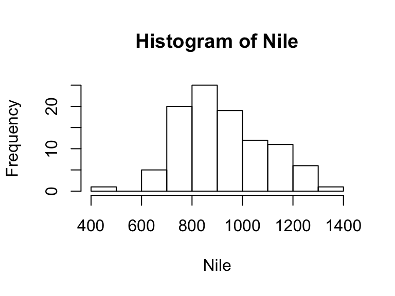

```r
hist(Nile)
```

## Add a Floating Table of Contents

```
---
title: "Measuring Nile Flow"
author: "Your Name Here"
date: "October 24, 2017"
output:
    html_document:
      toc: true
      toc_float: true
---
```

## Convert Your Document into a Slide Presentation

Pandoc will allow you to convert your html file into a slide presentation.

```
---
title: "Measuring Nile Flow"
author: "Your Name Here"
date: "October 24, 2017"
output: ioslides_presentation
---
```

## Including Shiny in R Markdown

- Shiny is an R framework for creating interactive web applications.
- Shiny widgets and apps can be embedded into an R markdown file, or exist as stand-alone applications.
- Lots of tutorials exist for creating Shiny applications or Shiny widgets embedded in R Markdown documents.

Here are some good ones:

- [Shiny R Studio tutorial](https://shiny.rstudio.com/articles/interactive-docs.html)
- [How to Build a Shiny App](http://shiny.rstudio.com/tutorial/)

## Exercise 3: Open Shiny_Nile.Rmd

File > New File > R Markdown > Shiny > Shiny Document

`output: html_document`  
`runtime: shiny`

Shiny documents have “Run Document” buttons. Click this to render the document.

When you save the file, you’ll notice that the “Run Document” button appears

## Shiny Code Chunk

After the line plot code, the highlighted code chunk to create an interactive histogram.

```r
# create dropdown selector for histogram
inputPanel(
  selectInput("n_breaks", label= "Bins", c(10, 20, 30, 40), selected = 10)  #creates a dropdown selector
)

# create histogram
renderPlot({
hist(Nile, xlab= "Measurement", probability = TRUE, breaks = as.numeric(input$n_breaks), col="deepskyblue3")
})
```

Run the document. The histogram will update when a new value is selected from the dropdown menu.

## Creating a Static Site

To create a static website with R Markdown, you need the following files:

- _site.yml
- an .Rmd file for every page

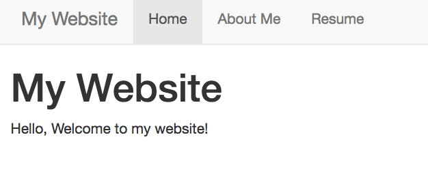

## Rendering Your Website

Inside directory that contains _site.yml and index.Rmd, you can run:

`rmarkdown::render_site()`

## Exercise 4: Open _site.yml file

Add resume.html

```
---
name: "my-website"
navbar:
  title: "My Website"
  left:
    - text: "Home"
      href: index.html
    - text: "About Me"
      href: about.html
    - text: "Resume"
      href: resume.html
---
```

## Create resume.html .Rmd file

```
---
Your Name
Address
Contact Info
<hr>

##### Education

##### Work Experience
---
```

## Render the site

Make sure you’re in the website directory

Type `rmarkdown::render_site()` in the console

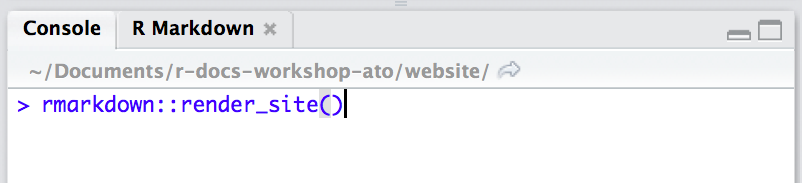